# R Notebook

# Leemos los df

```r
library(ggplot2)
# install.packages('pacman')
pacman::p_load(forecast)
dev.new(width=12, height=5)
knitr::opts_chunk$set(fig.width=12, fig.height=5)

# install.packages('tidyverse')
df_train = read.csv('data/train.csv')
df_train$Date = as.Date(df_train$Date)
df_test = read.csv('data/test.csv')
df_store = read.csv('data/store.csv')
head(df_store)
```

|  | Store | StoreType | Assortment | CompetitionDistance | CompetitionOpenSinceMonth | CompetitionOpenSinceYear | Promo2 | Promo2SinceWeek | Promo2SinceYear | PromoInterval |
| --- | --- | --- | --- | --- | --- | --- | --- | --- | --- | --- |
| 1 | 1 | c | a | 1270 | 9 | 2008 | 0 | NA | NA |  |
| 2 | 2 | a | a | 570 | 11 | 2007 | 1 | 13 | 2010 | Jan,Apr,Jul,Oct |
| 3 | 3 | a | a | 14130 | 12 | 2006 | 1 | 14 | 2011 | Jan,Apr,Jul,Oct |
| 4 | 4 | c | c | 620 | 9 | 2009 | 0 | NA | NA |  |
| 5 | 5 | a | a | 29910 | 4 | 2015 | 0 | NA | NA |  |
| 6 | 6 | a | a | 310 | 12 | 2013 | 0 | NA | NA |  |

```r
head(df_train)
```

|  | Store | DayOfWeek | Date | Sales | Customers | Open | Promo | StateHoliday | SchoolHoliday |
| --- | --- | --- | --- | --- | --- | --- | --- | --- | --- |
| 1 | 1 | 5 | 2015-07-31 | 5263 | 555 | 1 | 1 | 0 | 1 |
| 2 | 2 | 5 | 2015-07-31 | 6064 | 625 | 1 | 1 | 0 | 1 |
| 3 | 3 | 5 | 2015-07-31 | 8314 | 821 | 1 | 1 | 0 | 1 |
| 4 | 4 | 5 | 2015-07-31 | 13995 | 1498 | 1 | 1 | 0 | 1 |
| 5 | 5 | 5 | 2015-07-31 | 4822 | 559 | 1 | 1 | 0 | 1 |
| 6 | 6 | 5 | 2015-07-31 | 5651 | 589 | 1 | 1 | 0 | 1 |

```r
head(df_test)
```

|  | Id | Store | DayOfWeek | Date | Open | Promo | StateHoliday | SchoolHoliday |
| --- | --- | --- | --- | --- | --- | --- | --- | --- |
| 1 | 1 | 1 | 4 | 2015-09-17 | 1 | 1 | 0 | 0 |
| 2 | 2 | 3 | 4 | 2015-09-17 | 1 | 1 | 0 | 0 |
| 3 | 3 | 7 | 4 | 2015-09-17 | 1 | 1 | 0 | 0 |
| 4 | 4 | 8 | 4 | 2015-09-17 | 1 | 1 | 0 | 0 |
| 5 | 5 | 9 | 4 | 2015-09-17 | 1 | 1 | 0 | 0 |
| 6 | 6 | 10 | 4 | 2015-09-17 | 1 | 1 | 0 | 0 |

# Store con minima distancia

```r
min(df_store[!is.na(df_store$CompetitionDistance),'CompetitionDistance'])
```

```
[1] 20
```

```r
df_store[df_store$CompetitionDistance==20,]
```

|  | Store | StoreType | Assortment | CompetitionDistance | CompetitionOpenSinceMonth | CompetitionOpenSinceYear | Promo2 | Promo2SinceWeek | Promo2SinceYear | PromoInterval |
| --- | --- | --- | --- | --- | --- | --- | --- | --- | --- | --- |
| NA | NA | NA | NA | NA | NA | NA | NA | NA | NA | NA |
| 516 | 516 | a | c | 20 | NA | NA | 1 | 35 | 2010 | Mar,Jun,Sept,Dec |
| NA.1 | NA | NA | NA | NA | NA | NA | NA | NA | NA | NA |
| NA.2 | NA | NA | NA | NA | NA | NA | NA | NA | NA | NA |

# Obtenemos las stores de test

```r
stores_test = unique(df_test$Store)
```

#Filtramos del DF las stores de test

```r
df_train_filtered = df_train[df_train$Store %in% stores_test, ]
head(df_train_filtered)
```

|  | Store | DayOfWeek | Date | Sales | Customers | Open | Promo | StateHoliday | SchoolHoliday |
| --- | --- | --- | --- | --- | --- | --- | --- | --- | --- |
| 1 | 1 | 5 | 2015-07-31 | 5263 | 555 | 1 | 1 | 0 | 1 |
| 3 | 3 | 5 | 2015-07-31 | 8314 | 821 | 1 | 1 | 0 | 1 |
| 7 | 7 | 5 | 2015-07-31 | 15344 | 1414 | 1 | 1 | 0 | 1 |
| 8 | 8 | 5 | 2015-07-31 | 8492 | 833 | 1 | 1 | 0 | 1 |
| 9 | 9 | 5 | 2015-07-31 | 8565 | 687 | 1 | 1 | 0 | 1 |
| 10 | 10 | 5 | 2015-07-31 | 7185 | 681 | 1 | 1 | 0 | 1 |

# Filtramos la tienda 1

```r
df_train_tienda_1 = df_train_filtered[df_train_filtered$Store==1,]
head(df_train_tienda_1)
```

|  | Store | DayOfWeek | Date | Sales | Customers | Open | Promo | StateHoliday | SchoolHoliday |
| --- | --- | --- | --- | --- | --- | --- | --- | --- | --- |
| 1 | 1 | 5 | 2015-07-31 | 5263 | 555 | 1 | 1 | 0 | 1 |
| 1116 | 1 | 4 | 2015-07-30 | 5020 | 546 | 1 | 1 | 0 | 1 |
| 2231 | 1 | 3 | 2015-07-29 | 4782 | 523 | 1 | 1 | 0 | 1 |
| 3346 | 1 | 2 | 2015-07-28 | 5011 | 560 | 1 | 1 | 0 | 1 |
| 4461 | 1 | 1 | 2015-07-27 | 6102 | 612 | 1 | 1 | 0 | 1 |
| 5576 | 1 | 7 | 2015-07-26 | 0 | 0 | 0 | 0 | 0 | 0 |

# Filtramos la tienda 3

```r
df_train_tienda_3 = df_train_filtered[df_train_filtered$Store==3,]
head(df_train_tienda_3)
```

|  | Store | DayOfWeek | Date | Sales | Customers | Open | Promo | StateHoliday | SchoolHoliday |
| --- | --- | --- | --- | --- | --- | --- | --- | --- | --- |
| 3 | 3 | 5 | 2015-07-31 | 8314 | 821 | 1 | 1 | 0 | 1 |
| 1118 | 3 | 4 | 2015-07-30 | 8977 | 823 | 1 | 1 | 0 | 1 |
| 2233 | 3 | 3 | 2015-07-29 | 7610 | 716 | 1 | 1 | 0 | 1 |
| 3348 | 3 | 2 | 2015-07-28 | 8864 | 818 | 1 | 1 | 0 | 1 |
| 4463 | 3 | 1 | 2015-07-27 | 8107 | 768 | 1 | 1 | 0 | 1 |
| 5578 | 3 | 7 | 2015-07-26 | 0 | 0 | 0 | 0 | 0 | 0 |

# Chequeo de la cantidad de días con venta en el día domingo

```r
nrow(df_train_filtered[(df_train_filtered$DayOfWeek==7),])
```

```
[1] 110024
```

```r
nrow(df_train_filtered[(df_train_filtered$DayOfWeek==7)&(df_train_filtered$Sales==0),])
```

```
[1] 107075
```

# Correlación cruzada con convolve de la ventas tienda 1, y clientes

[figure not shown]

```r
df_train_tienda_1$ventas_clientes = convolve(df_train_tienda_1$Sales, df_train_tienda_1$Customers, conj = TRUE)

ggplot(df_train_tienda_1, aes(x = Date, y = ventas_clientes)) +
    geom_line(color="green", size = 1.2) +
    theme_minimal() +
    theme(axis.text.x = element_text(angle = 90, hjust = 1)) +
    ggtitle("Cantidad de personas premium a lo largo de los últimos años")
```

# Correlación cruzada Clientes Ventas

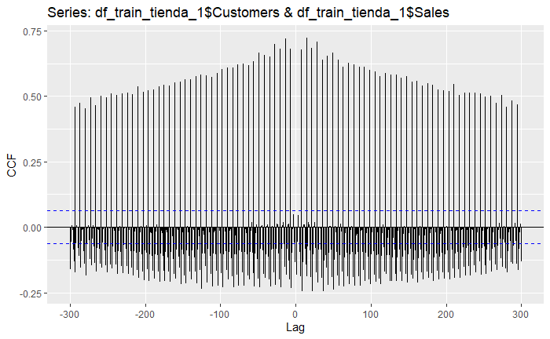

```r
ggCcf(df_train_tienda_1$Customers, df_train_tienda_1$Sales,lag.max = 300)
```

# Autocorrelación de la serie de ventas

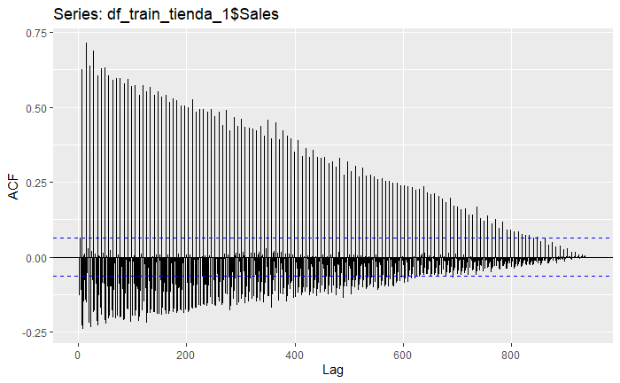

```r
ggAcf(df_train_tienda_1$Sales, lag.max = length(df_train_tienda_1$Sales))
```

# Correlación cruzada tienda 1 y 3

[figure not shown]

```r
ggplot(df_train_tienda_1, aes(x = Date, y = Sales)) +
    geom_line(color="red", size = 1.2) +
    theme_minimal() +
    theme(axis.text.x = element_text(angle = 90, hjust = 1)) +
    ggtitle("Ventas Tienda 1 y 3") +
    xlab("Fecha") +
    ylab("Ventas")
```

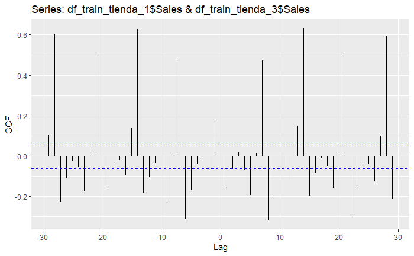

```r
ggCcf(df_train_tienda_1$Sales,df_train_tienda_3$Sales)
```

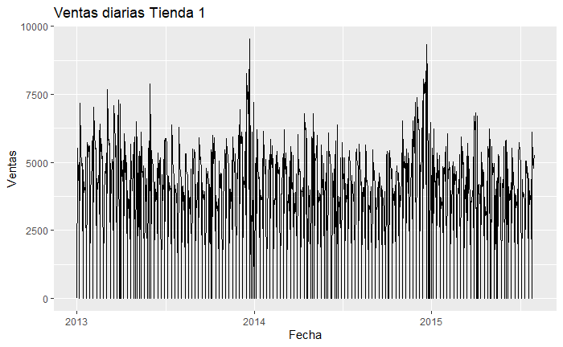

```r
library(tidyverse)
library(ggplot2)
library(tsibble)
library(feasts)
y <- tsibble(
  Date = df_train_tienda_1$Date,
  Sales = df_train_tienda_1$Sales,
  index = Date
)
autoplot(y,Sales) +
  labs(title = "Ventas diarias Tienda 1",
       y = "Ventas", x='Fecha')
```

#Filtrando cuando se encuentra cerrado

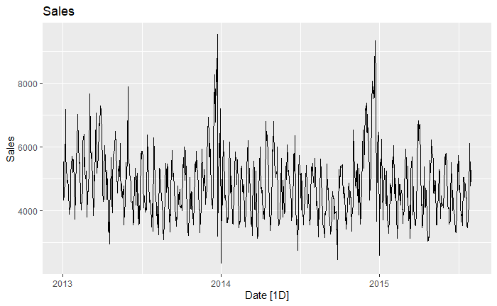

```r
melsyd_economy <- df_train_filtered %>%
  filter(Open == 1, Store == 1) %>%
  as_tsibble(index = Date)

autoplot(melsyd_economy, Sales) +
  labs(title = "Sales")
```

```r
melsyd_economy <- df_train_filtered %>%
  filter(Store == 1) %>%
  mutate(Sales = ifelse(Open == 1, Sales, NA),
         Customers = ifelse(Open == 1, Customers, NA),
         Promo = ifelse(Open == 1, Promo, NA),
         StateHoliday = ifelse(Open == 1, StateHoliday, NA),
         SchoolHoliday = ifelse(Open == 1, SchoolHoliday, NA),
         ) %>%
  as_tsibble(index = Date)
```

# Se puede observar cierta estacionalidad a lo largo del año

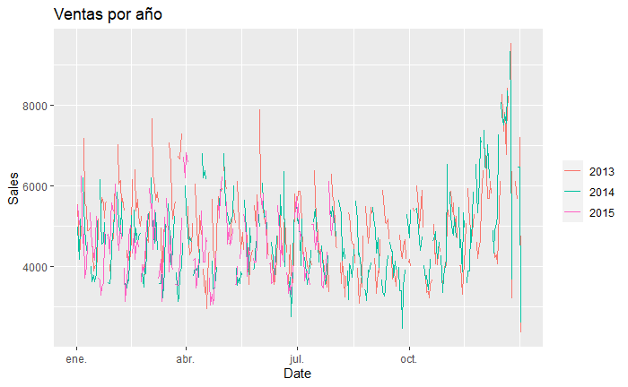

```r
melsyd_economy %>%
  gg_season(Sales) +
  labs(title = "Ventas por año")
```

# Estacionalidad semanal

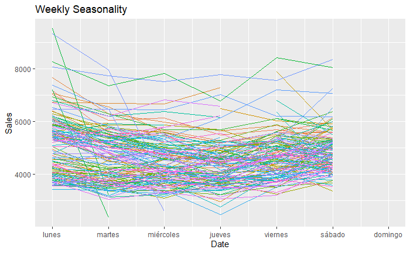

```r
melsyd_economy %>% gg_season(Sales, period = "week") +
  theme(legend.position = "none") +
  labs(title="Weekly Seasonality")
```

# Boxplots estacionalidad semanal

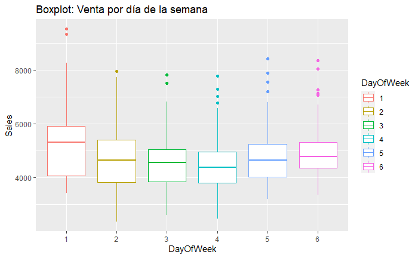

```r
ggplot(melsyd_economy %>%
  filter(Open==1) %>%
    mutate(DayOfWeek = as.factor(DayOfWeek)),  aes(x= DayOfWeek, y=Sales, color = DayOfWeek)) + ggtitle('Boxplot: Venta por día de la semana') +
  geom_boxplot()
```

# La mediana y los extramos de la caja se comportan de manera distinta dependiendo el día de la semana

# Estacionalidad anual

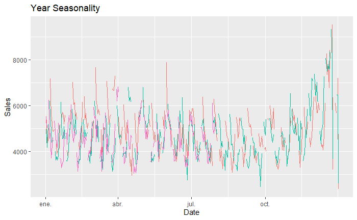

```r
melsyd_economy %>% gg_season(Sales, period = "year") +
  theme(legend.position = "none") +
  labs(title="Year Seasonality")
```

#Subseries Plot, estacionalidad dentro de la semana

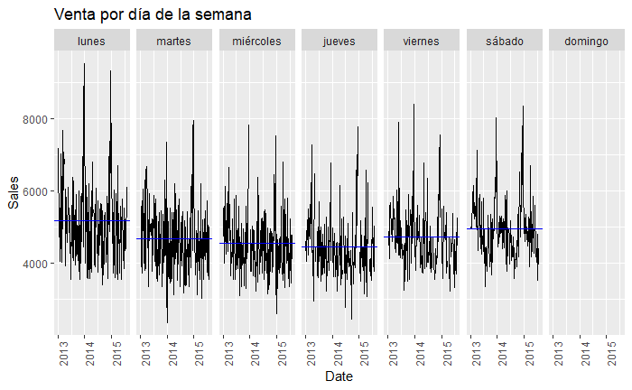

```r
melsyd_economy %>%
  gg_subseries(Sales,period = 'week') +
  labs(title = "Venta por día de la semana"
  )
```

# Venta a lo largo del día del mes

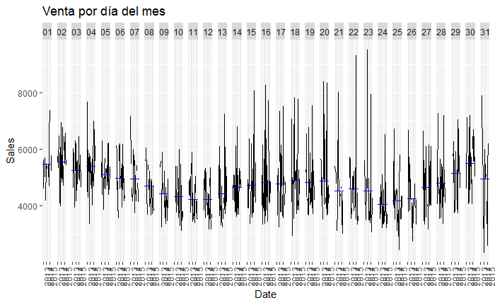

```r
melsyd_economy %>%
  gg_subseries(Sales,period = 'month') +
  labs(title = "Venta por día del mes"
  )
```

# Boxplot Estacionalidad a lo largo del mes

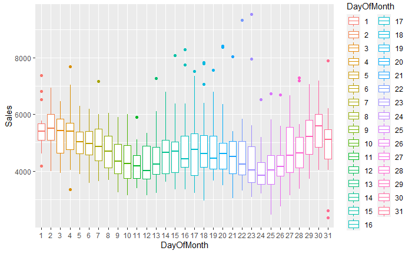

```r
ggplot(melsyd_economy %>%
  filter(Open==1) %>%
    mutate(DayOfMonth = as.factor(lubridate::day(Date))),  aes(x= DayOfMonth, y=Sales, color = DayOfMonth)) +
  geom_boxplot()
```

# Días para que termine el mes

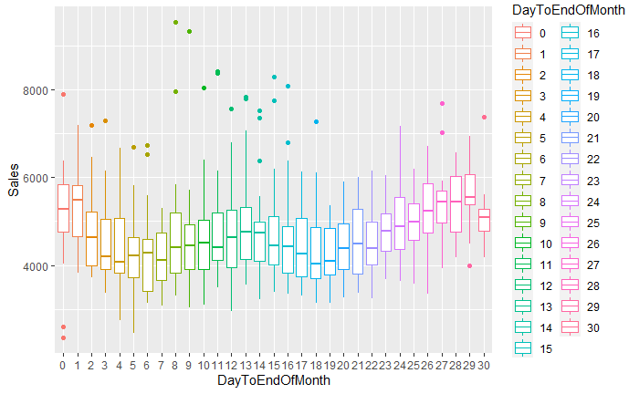

```r
ggplot(melsyd_economy %>%
  filter(Open==1) %>%
    mutate(DayToEndOfMonth = as.factor(lubridate::days_in_month(Date) - lubridate::day(Date))),  aes(x= DayToEndOfMonth, y=Sales, color = DayToEndOfMonth)) +
  geom_boxplot()
```

# Cuando faltan pocos días para que termine el mes la venta es alta.

# Día posterior a día cerrado

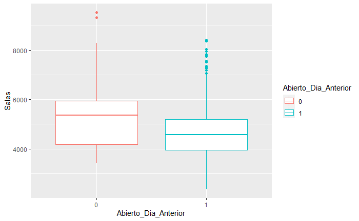

```r
ggplot(melsyd_economy %>%
    mutate(Abierto_Dia_Anterior = as.factor(lag(Open))) %>%
    filter(Open==1) ,  aes(x= Abierto_Dia_Anterior, y=Sales, color = Abierto_Dia_Anterior)) +
  geom_boxplot()
```

# Día posterior a día cerrado, excluyendo lunes, dado que todos los domingos se encuentra cerrado

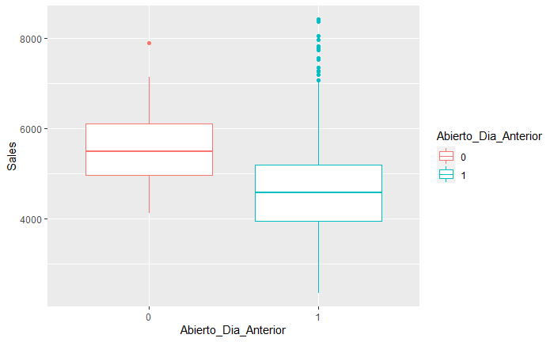

```r
ggplot(melsyd_economy %>%
    mutate(Abierto_Dia_Anterior = as.factor(lag(Open))) %>%
    filter(Open==1, DayOfWeek!=1) ,  aes(x= Abierto_Dia_Anterior, y=Sales, color = Abierto_Dia_Anterior)) +
  geom_boxplot()
```

# Boxplots Efecto de vacaciones de escuela

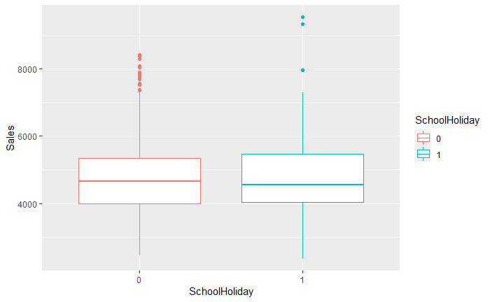

```r
ggplot(melsyd_economy %>%
  filter(Open==1) %>%
    mutate(SchoolHoliday = as.factor(SchoolHoliday)),  aes(x= SchoolHoliday, y=Sales, color = SchoolHoliday)) +
  geom_boxplot()
```

# La mediana parece ser más baja, no obstante hay mucho solapamiento

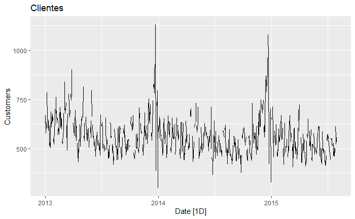

```r
melsyd_economy %>%
  autoplot(Customers) +
  labs(
    title = "Clientes"
  )
```

# Scatter Plot Clientes y Ventas

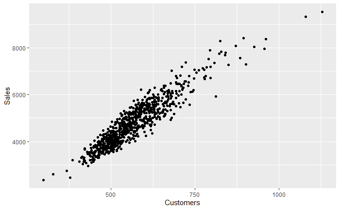

```r
melsyd_economy %>%
  ggplot(aes(x = Customers, y = Sales)) +
  geom_point()
```

# Alta correlación entre clientes y ventas

```r
cor(df_train_tienda_1$Customers, df_train_tienda_1$Sales)
```

```
[1] 0.9843412
```

```r
cor(df_train_tienda_1$Customers, df_train_tienda_1$Sales, method = 'spearman')
```

```
[1] 0.9554348
```